# **Final Project**

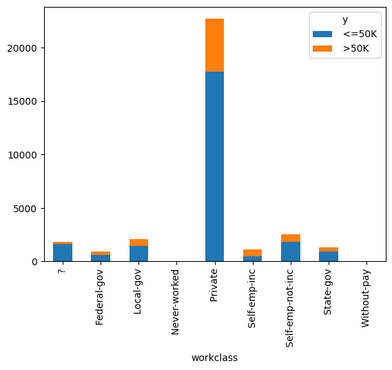

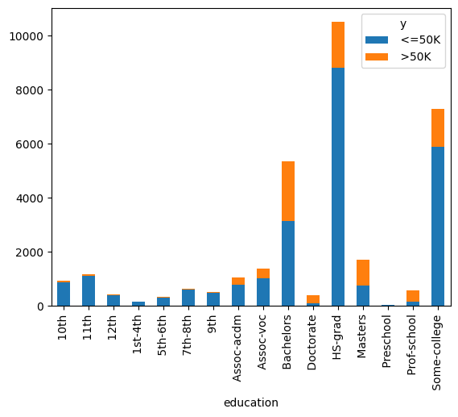

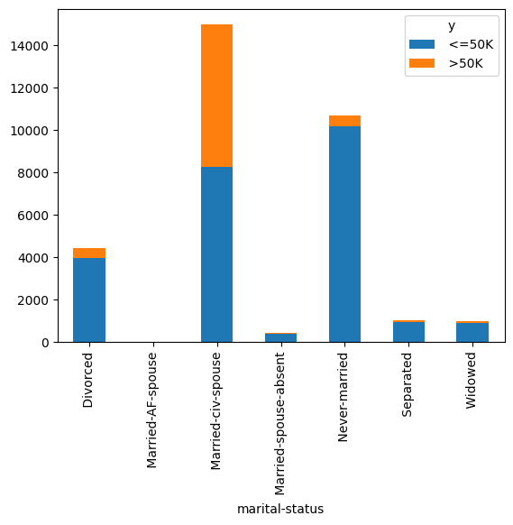

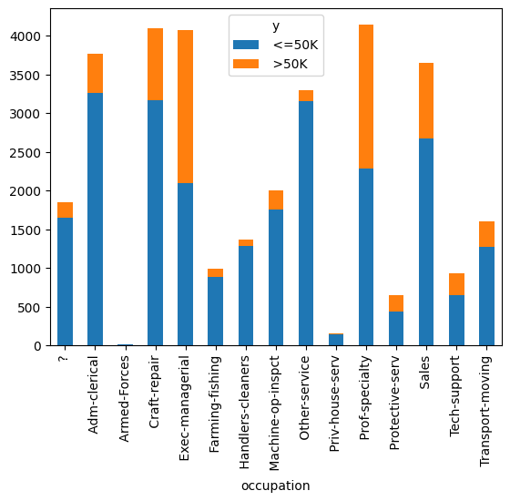

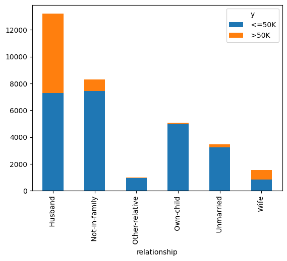

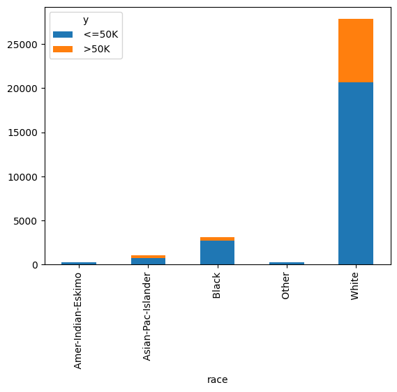

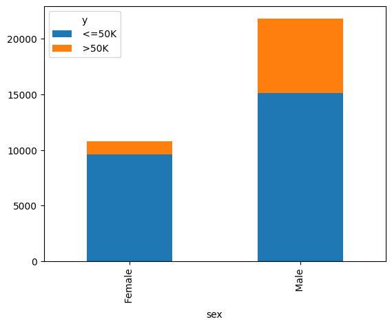

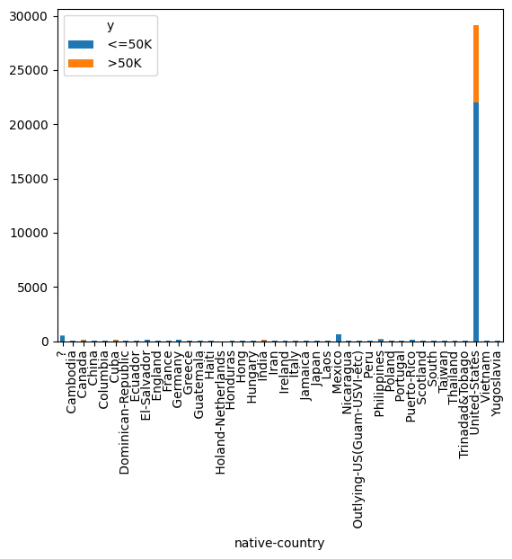

```python
for predictor in categorical_predictors:
    pd.crosstab(p1_data[predictor], p1_data['y']).plot(kind='bar', stacked=True)
    plt.show()
```

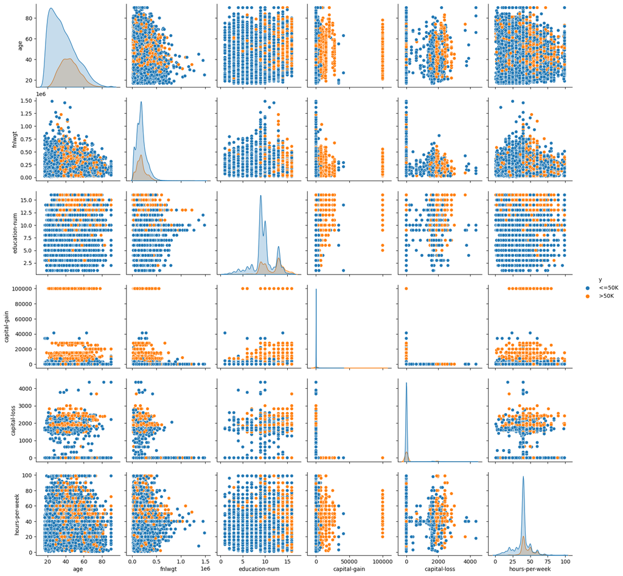

```python
sns.pairplot(p1_data[['age', 'workclass', 'fnlwgt', 'education', 'education-num', 'marital-status', 'occupation', 'relationship', 'race', 'sex',
                      'capital-gain', 'capital-loss', 'hours-per-week', 'native-country', 'y']],hue='y')
```

### Predictors that Appear to Have a Relationship with the Target Variable

Color-coding the above pairplot by the target variable where blue dots represent the <=50K (1) class and the orange dots represent the >50K (0) class, reveals some patterns in the data by the target variable. The capital gain column shows that class 1 is often clustered to the left of the graph where class 0 is clustered more towards the right of the graph. Therefore, we see that those with incomes over 50K tend to have higher capital-gains. Additionally, those with higher education numbers (i.e., higher education levels) tend to be those with incomes over 50K. Looking at the stacked bar charts for categorical columns by the target variable, we see that men have a higher proportion of incomes over 50K than women do. We can also see that individuals in the white race category also have a higher proportion of individuals with incomes over 50K than other race categories do. Individuals with the relationship 'husband' have a higher proportion of individuals with incomes over 50K as well. Job roles Exec-managerial and Prof-speciality have a higher proportion of individuals with incomes over 50K. Finally, those with Bachelor's degrees also have a higher proportion of incomes over 50K.

## Data Encoding

### Pop the Target Variable

```python
y_target = p1_data.pop('y')
```

### Encode the Target Variable

```python
y_target = y_target.str.strip().eq('<=50K').mul(1)
```

The .str.strip() code is removing blank spaces before the <50K that was causing issues when trying to encode the target variable. The target variable is necessary to encode because it is categorical.

```python
y_target.head()
```

```
0    1
1    1
2    1
3    1
4    1
Name: y, dtype: int64
```

```python
filtered_values = y_target[y_target == 0]

print(filtered_values)
```

```
7        0
8        0
9        0
10       0
11       0
        ..
32539    0
32545    0
32554    0
32557    0
32560    0
Name: y, Length: 7841, dtype: int64
```

### Dataframe Shape Pre-Encoding

```python
p1_data.shape
```

```
(32561, 14)
```

### Encoding the Dataframe

```python
X = pd.get_dummies(p1_data)
```

```python
X.head()
```

|  | age | fnlwgt | education-num | capital-gain | capital-loss | hours-per-week | workclass_ ? | workclass_ Federal-gov | workclass_ Local-gov | workclass_ Never-worked | ... | native-country_ Portugal | native-country_ Puerto-Rico | native-country_ Scotland | native-country_ South | native-country_ Taiwan | native-country_ Thailand | native-country_ Trinadad&Tobago | native-country_ United-States | native-country_ Vietnam | native-country_ Yugoslavia |
| --- | --- | --- | --- | --- | --- | --- | --- | --- | --- | --- | --- | --- | --- | --- | --- | --- | --- | --- | --- | --- | --- |
| 0 | 39 | 77516 | 13 | 2174 | 0 | 40 | 0 | 0 | 0 | 0 | ... | 0 | 0 | 0 | 0 | 0 | 0 | 0 | 1 | 0 | 0 |
| 1 | 50 | 83311 | 13 | 0 | 0 | 13 | 0 | 0 | 0 | 0 | ... | 0 | 0 | 0 | 0 | 0 | 0 | 0 | 1 | 0 | 0 |
| 2 | 38 | 215646 | 9 | 0 | 0 | 40 | 0 | 0 | 0 | 0 | ... | 0 | 0 | 0 | 0 | 0 | 0 | 0 | 1 | 0 | 0 |
| 3 | 53 | 234721 | 7 | 0 | 0 | 40 | 0 | 0 | 0 | 0 | ... | 0 | 0 | 0 | 0 | 0 | 0 | 0 | 1 | 0 | 0 |
| 4 | 28 | 338409 | 13 | 0 | 0 | 40 | 0 | 0 | 0 | 0 | ... | 0 | 0 | 0 | 0 | 0 | 0 | 0 | 0 | 0 | 0 |

5 rows × 108 columns

### Dataframe Shape Post-Encoding

```python
X.shape
```

```
(32561, 108)
```

### Difference in Pre- and Post-Encoded Dataframe

After encoding the dataframe, the number of columns has increased while the number of rows has remained the same. This is because all of the categorical columns were broken down into their sub-options (e.g., workclass is now: workclass_Federal-gov, workclass_Local-gov, and so forth) and then encoded as either 1 (yes it is that value) or 0 (no it is not that value).

## Task 5: Model Building & Evaluation

### Decision Tree

```python
dt_param_grid = {
    'criterion': ['gini', 'entropy'],
    'random_state': [42],
    'max_depth': [None, 10, 20, 30],
    'min_samples_split': [2, 5, 10],
    'min_samples_leaf': [1, 2, 4]
}
```

```python
dt_model = DecisionTreeClassifier()
dt_grid_search = GridSearchCV(dt_model, dt_param_grid, cv=5, scoring=['accuracy', 'precision', 'recall', 'f1'], refit=False, return_train_score=True)
dt_grid_search.fit(X, y_target)
```

```
GridSearchCV(cv=5, estimator=DecisionTreeClassifier(),
             param_grid={'criterion': ['gini', 'entropy'],
                         'max_depth': [None, 10, 20, 30],
                         'min_samples_leaf': [1, 2, 4],
                         'min_samples_split': [2, 5, 10],
                         'random_state': [42]},
             refit=False, return_train_score=True,
             scoring=['accuracy', 'precision', 'recall', 'f1'])
```

```python
grid_search_df = pd.DataFrame(dt_grid_search.cv_results_)
grid_search_df = round(grid_search_df,4)
grid_search_df = grid_search_df.sort_values('rank_test_f1')[['rank_test_f1','params','mean_test_accuracy', 'mean_test_precision', 'mean_test_recall', 'mean_test_f1', 'mean_train_f1']]
grid_search_df.head()
```

|  | rank_test_f1 | params | mean_test_accuracy | mean_test_precision | mean_test_recall | mean_test_f1 | mean_train_f1 |
| --- | --- | --- | --- | --- | --- | --- | --- |
| 9 | 1 | {'criterion': 'gini', 'max_depth': 10, 'min_sa... | 0.8556 | 0.8800 | 0.9379 | 0.9079 | 0.9186 |
| 17 | 2 | {'criterion': 'gini', 'max_depth': 10, 'min_sa... | 0.8556 | 0.8810 | 0.9364 | 0.9078 | 0.9165 |
| 15 | 3 | {'criterion': 'gini', 'max_depth': 10, 'min_sa... | 0.8556 | 0.8810 | 0.9363 | 0.9078 | 0.9166 |
| 16 | 3 | {'criterion': 'gini', 'max_depth': 10, 'min_sa... | 0.8556 | 0.8810 | 0.9363 | 0.9078 | 0.9166 |
| 11 | 5 | {'criterion': 'gini', 'max_depth': 10, 'min_sa... | 0.8554 | 0.8801 | 0.9373 | 0.9077 | 0.9177 |

Decision Tree Models are used for classification or regression tasks. In this case, the decision tree is used for classifcation. These models have decision nodes where a feature will split the data into groups. The model will attempt to choose the feature that best separates the data into a distinct group.

### SVM

```python
parameters = {'C':[0.1, 1, 10]
              }
```

```python
svc = SVC(random_state=42)
clf = GridSearchCV(svc, parameters,scoring=['accuracy', 'precision', 'f1'], refit=False, return_train_score=True)
clf.fit(X, y_target)
```

```
GridSearchCV(estimator=SVC(random_state=42), param_grid={'C': [0.1, 1, 10]},
             refit=False, return_train_score=True,
             scoring=['accuracy', 'precision', 'f1'])
```

```python
grid_search_df = pd.DataFrame(clf.cv_results_)
grid_search_df = round(grid_search_df,4)
grid_search_df = grid_search_df.sort_values('rank_test_f1')[['rank_test_f1','params','mean_test_accuracy', 'mean_test_precision', 'mean_test_f1', 'mean_train_f1']]
grid_search_df.head()
```

|  | rank_test_f1 | params | mean_test_accuracy | mean_test_precision | mean_test_f1 | mean_train_f1 |
| --- | --- | --- | --- | --- | --- | --- |
| 2 | 1 | {'C': 10} | 0.7976 | 0.7951 | 0.8811 | 0.8813 |
| 1 | 2 | {'C': 1} | 0.7949 | 0.7878 | 0.8809 | 0.8809 |
| 0 | 3 | {'C': 0.1} | 0.7639 | 0.7629 | 0.8654 | 0.8654 |

SVM (support vector machine) models are good for classification or regression. They are good for tasks where the data points are not linearly separable. When looking at the pairplot in Task 5, a lot of the interaction between two different columns does not appear to be linear. Therefore, this model could be a good approach when dealing with this nonlinear data.

This model yieled a relatively high mean test f1 score at 0.88. This model had a C value equal to 10. All three SVC models had either the same or very close in value mean_test_f1 and mean_train_f1 scores, which indicates that overfitting has not occured as there is no drop off in performance between the train and test score. However, there was a noticeable drop off in model performance on all three scoring metrics when the C parameter was equal to 0.1. Thus, this parameter value should likely not be used.

### MLP

```python
mlp_param_grid = {
    'hidden_layer_sizes': [(10,), (20, 20), (30, 30, 30)],
    'activation': ['relu', 'logistic']
}
```

```python
mlp = MLPClassifier(random_state=2021)
clf = GridSearchCV(mlp, mlp_param_grid, scoring=['accuracy', 'precision', 'f1'], refit=False, return_train_score=True, cv=5)
clf.fit(X, y_target)
```

```
GridSearchCV(cv=5, estimator=MLPClassifier(random_state=2021),
             param_grid={'activation': ['relu', 'logistic'],
                         'hidden_layer_sizes': [(10,), (20, 20), (30, 30, 30)]},
             refit=False, return_train_score=True,
             scoring=['accuracy', 'precision', 'f1'])
```

```python
grid_search_df = pd.DataFrame(clf.cv_results_)
grid_search_df = round(grid_search_df,4)
grid_search_df = grid_search_df.sort_values('rank_test_f1')[['rank_test_f1','params','mean_test_accuracy', 'mean_test_precision', 'mean_test_f1', 'mean_train_f1']]
top_5_results = grid_search_df.head(5)
display(top_5_results)
```

|  | rank_test_f1 | params | mean_test_accuracy | mean_test_precision | mean_test_f1 | mean_train_f1 |
| --- | --- | --- | --- | --- | --- | --- |
| 1 | 1 | {'activation': 'relu', 'hidden_layer_sizes': (... | 0.7873 | 0.7963 | 0.8736 | 0.8735 |
| 0 | 2 | {'activation': 'relu', 'hidden_layer_sizes': (... | 0.7888 | 0.8345 | 0.8660 | 0.8666 |
| 5 | 3 | {'activation': 'logistic', 'hidden_layer_sizes... | 0.7621 | 0.7614 | 0.8645 | 0.8648 |
| 3 | 4 | {'activation': 'logistic', 'hidden_layer_sizes... | 0.7603 | 0.7600 | 0.8637 | 0.8637 |
| 4 | 5 | {'activation': 'logistic', 'hidden_layer_sizes... | 0.7592 | 0.7592 | 0.8631 | 0.8631 |

MLP stands for Multilayered Perceptron. This model is a type of ANN model (Artifical Neural Network Model). MLPs are good for classification, regression, and pattern recognition tasks.

From the results above, we see the best MLP model had a mean test score of 0.8736 and a mean train score of 0.8735, which indicates that overfitting has not occured as there is no drop off in performance between the train and test score. The model that achieved the highest rank_test_score used the relu activation and two hidden layers with 20 neurons each. There was only one model in the top five that had three hidden layers, while the models with two hidden layers seemed to perform the best.

```python
majority_model = DummyClassifier(strategy='uniform')
majority_model.fit(X, y_target)
```

```
DummyClassifier(strategy='uniform')
```

```python
majority_predictions = majority_model.predict(X)
```

```python
scores = cross_validate(
    DecisionTreeClassifier(
        ccp_alpha=0.01),
        X,
        y_target,
        cv=StratifiedKFold(
            n_splits=3,
            shuffle=True,
            random_state=True),
        scoring=['accuracy','recall','precision', 'f1'],
        return_train_score=True)
pd.DataFrame(scores)
```

|  | fit_time | score_time | test_accuracy | train_accuracy | test_recall | train_recall | test_precision | train_precision | test_f1 | train_f1 |
| --- | --- | --- | --- | --- | --- | --- | --- | --- | --- | --- |
| 0 | 0.301505 | 0.024266 | 0.842639 | 0.844336 | 0.949272 | 0.947876 | 0.858428 | 0.861088 | 0.901568 | 0.902400 |
| 1 | 0.317481 | 0.021685 | 0.847982 | 0.841664 | 0.947209 | 0.948908 | 0.865299 | 0.857676 | 0.904403 | 0.900988 |
| 2 | 0.340214 | 0.023609 | 0.840689 | 0.845310 | 0.948544 | 0.948240 | 0.856924 | 0.861846 | 0.900409 | 0.902982 |

```python
print(confusion_matrix(y_true=y_target,y_pred=majority_model.predict(X)))
```

```
[[ 3822  4019]
 [12410 12310]]
```

### KNN

```python
scaler = StandardScaler()
data_scaled = scaler.fit_transform(X)
```

```python
X_scaled_df = pd.DataFrame(data_scaled, columns=X.columns)
display(X_scaled_df.head())
```

|  | age | fnlwgt | education-num | capital-gain | capital-loss | hours-per-week | workclass_ ? | workclass_ Federal-gov | workclass_ Local-gov | workclass_ Never-worked | ... | native-country_ Portugal | native-country_ Puerto-Rico | native-country_ Scotland | native-country_ South | native-country_ Taiwan | native-country_ Thailand | native-country_ Trinadad&Tobago | native-country_ United-States | native-country_ Vietnam | native-country_ Yugoslavia |
| --- | --- | --- | --- | --- | --- | --- | --- | --- | --- | --- | --- | --- | --- | --- | --- | --- | --- | --- | --- | --- | --- |
| 0 | 0.030671 | -1.063611 | 1.134739 | 0.148453 | -0.21666 | -0.035429 | -0.24445 | -0.174295 | -0.262097 | -0.014664 | ... | -0.033729 | -0.059274 | -0.019201 | -0.049628 | -0.039607 | -0.023518 | -0.024163 | 0.340954 | -0.045408 | -0.022173 |
| 1 | 0.837109 | -1.008707 | 1.134739 | -0.145920 | -0.21666 | -2.222153 | -0.24445 | -0.174295 | -0.262097 | -0.014664 | ... | -0.033729 | -0.059274 | -0.019201 | -0.049628 | -0.039607 | -0.023518 | -0.024163 | 0.340954 | -0.045408 | -0.022173 |
| 2 | -0.042642 | 0.245079 | -0.420060 | -0.145920 | -0.21666 | -0.035429 | -0.24445 | -0.174295 | -0.262097 | -0.014664 | ... | -0.033729 | -0.059274 | -0.019201 | -0.049628 | -0.039607 | -0.023518 | -0.024163 | 0.340954 | -0.045408 | -0.022173 |
| 3 | 1.057047 | 0.425801 | -1.197459 | -0.145920 | -0.21666 | -0.035429 | -0.24445 | -0.174295 | -0.262097 | -0.014664 | ... | -0.033729 | -0.059274 | -0.019201 | -0.049628 | -0.039607 | -0.023518 | -0.024163 | 0.340954 | -0.045408 | -0.022173 |
| 4 | -0.775768 | 1.408176 | 1.134739 | -0.145920 | -0.21666 | -0.035429 | -0.24445 | -0.174295 | -0.262097 | -0.014664 | ... | -0.033729 | -0.059274 | -0.019201 | -0.049628 | -0.039607 | -0.023518 | -0.024163 | -2.932948 | -0.045408 | -0.022173 |

5 rows × 108 columns

The data going into the KNN model should be standardized because KNN models rely on distance measures and if the distances are on different scales, then a feature with a larger scale could dominate the calculation of distance.

```python
knn_param_grid = {
    'n_neighbors': range(1, 11),
    'weights': ['uniform', 'distance']
}
```

```python
knn = KNeighborsClassifier()
grid_search = GridSearchCV(knn, knn_param_grid, scoring=['accuracy', 'precision', 'f1'], cv=5, refit=False, return_train_score=True)
grid_search.fit(data_scaled, y_target)
```

```
GridSearchCV(cv=5, estimator=KNeighborsClassifier(),
             param_grid={'n_neighbors': range(1, 11),
                         'weights': ['uniform', 'distance']},
             refit=False, return_train_score=True,
             scoring=['accuracy', 'precision', 'f1'])
```

```python
results = pd.DataFrame(grid_search.cv_results_)
results = round(results,4)
results = results.sort_values('rank_test_f1')[['rank_test_f1','params','mean_test_accuracy', 'mean_train_accuracy', 'mean_test_precision', 'mean_train_precision', 'mean_test_f1', 'mean_train_f1']]
results.head()
```

|  | rank_test_f1 | params | mean_test_accuracy | mean_train_accuracy | mean_test_precision | mean_train_precision | mean_test_f1 | mean_train_f1 |
| --- | --- | --- | --- | --- | --- | --- | --- | --- |
| 16 | 1 | {'n_neighbors': 9, 'weights': 'uniform'} | 0.8264 | 0.8583 | 0.8677 | 0.8883 | 0.8884 | 0.9088 |
| 12 | 2 | {'n_neighbors': 7, 'weights': 'uniform'} | 0.8247 | 0.8647 | 0.8681 | 0.8932 | 0.8871 | 0.9129 |
| 19 | 3 | {'n_neighbors': 10, 'weights': 'distance'} | 0.8236 | 1.0000 | 0.8671 | 1.0000 | 0.8864 | 1.0000 |
| 15 | 4 | {'n_neighbors': 8, 'weights': 'distance'} | 0.8237 | 1.0000 | 0.8685 | 1.0000 | 0.8863 | 1.0000 |
| 17 | 5 | {'n_neighbors': 9, 'weights': 'distance'} | 0.8234 | 1.0000 | 0.8674 | 1.0000 | 0.8862 | 1.0000 |

KNN stands for K-Nearest Neighbors. This model is used for classification or regression tasks. It does not make assumptions about the underlying data and will only make assumptions based on the similarity between the new data and the existing data points.

From the results above, we can see that a higher number of n_neighbors led to better model performance. Additionally, the two models with uniform weights had better performance. The best performing model had 9 n_neighbors and a uniform weight. However, models ranked 3 - 5 exhibited pretty signifcant overfitting. These models all experienced an 11% drop-off in the mean_f1 and mean_precision scores from the training to testing models. They also all experienced an 18% drop-off in the mean_accuracy score from the train to test models. This highlights the earlier mentioned problem of an imbalanced target variable.

### Models In Summary: Models That Stood Out & Metrics Used to Evaluate Them

While the top result from all of the different models performed in relatively the same range, the Decision Tree and the KNN models performed the best in terms of f1-score with scores of 0.91 and 0.89, respectively. These models also had some of the highest precision metrics at 0.88 and 0.87, respectively. If comparing all the models only on an f1-score, the MLP model (rank 1) performed the worst at 0.87. However, this score is still pretty comparable to the other models.

I was using F1 score, precision, and accuracy metrics to evaluate each of these models. A strength of the F1 score is that it considers both precision and recall, providing a more wholistic overview of model performance. Additionally, it is useful for imabalanced datasets. However, a weakness of the F1 score metric is that, in the case of a model needing one class to be better predicted than another, it would not be as useful in showing false positives or false negatives individually. For example, if we discovered that the cost of false positives is high, then we would want to focus more on precision rather than the F1 score.

A srength of the precision metric is that it can help show if there is a high ratio of false positives in the dataset. A weakness is that precision doesn't consider false negatives. This could be problematic in a model with a high rate of false negatives.

A srength of the accuracy metric is that it is easily interpretable and widely adopted. This metric provides an overall measure of model performance. It is also useful for balanced data sets. A weakness of the accuracy metric is that it can be misleading for imbalanced datasets like this one. When looking at accuracy alone, it can be difficult to identify specific types of errors (e.g. too many FP or FN errors).

## Task 7: Final Model Recommendation

The model that performed the best was the Decision Tree Model with these parameters:

{'criterion': 'gini', 'max_depth': 10, 'min_samples_leaf': 1, 'min_samples_split': 2, 'random_state': 42}